# Notebook

### Objective

Predict customer churn for a telecommunications company using the available dataset. Analyze customer data, including demographics, services, account information, and churn status, to develop targeted customer retention programs and help the company reduce customer attrition. Apply data exploration, preprocessing, feature engineering, and machine learning techniques to create a churn prediction model.

| Variables | object | DataType |
| --- | --- | --- |
| CustomeID |  | object |
| Gender | male/female | object |
| SeniorCitizen | Whether the customer is a senior citizen or not (1, 0) | int64 |
| Partner | Whether the customer has a partner or not (Yes, No) | object |
| Dependents | Whether the customer has dependents or not (Yes, No) | object |
| tenure | Number of months the customer has stayed with the company | int64 |
| MultipleLines | Whether the customer has a phone service or not (Yes, No) | object |
| InternetService | Customer’s internet service provider (DSL, Fiber optic, No) | object |
| OnlineSecurity | Whether the customer has online security or not (Yes, No, No internet service) | object |
| OnlineBackup | Whether the customer has online backup or not (Yes, No, No internet service) | object |
| DeviceProtection | Whether the customer has device protection or not (Yes, No, No internet service) | object |
| TechSupport | Whether the customer has tech support or not (Yes, No, No internet service) | object |
| StreamingTV | Whether the customer has streaming TV or not (Yes, No, No internet service) | object |
| StreamingMovies | Whether the customer has streaming movies or not (Yes, No, No internet service) | object |
| Contract | The contract term of the customer (Month-to-month, One year, Two year) | object |
| PaperlessBilling | Whether the customer has paperless billing or not (Yes, No) | object |
| PaymentMethod | The customer’s payment method (Electronic check, Mailed check, Bank transfer (automatic), Credit card (automatic)) | object |
| MonthlyCharges | The amount charged to the customer monthly | float64 |
| TotalCharges | The total amount charged to the customer | object |
| Churn | Whether the customer churned or not (Yes or No) | object |

## Data exploration and analysis

```python
### Import Libaray ###
import pandas as pd
import matplotlib.pyplot as plt
import numpy as np
from plotly.subplots import make_subplots
import plotly.graph_objects as go
import plotly.express as px
from matplotlib.cm import rainbow
import seaborn as sns
import plotly.io as pio

print('Done')
```

```
Done
```

```python
Cu_data = pd.read_csv('WA_Fn-UseC_-Telco-Customer-Churn.csv')
```

```python
Cu_data.head()
```

|  | customerID | gender | SeniorCitizen | Partner | Dependents | tenure | PhoneService | MultipleLines | InternetService | OnlineSecurity | ... | DeviceProtection | TechSupport | StreamingTV | StreamingMovies | Contract | PaperlessBilling | PaymentMethod | MonthlyCharges | TotalCharges | Churn |
| --- | --- | --- | --- | --- | --- | --- | --- | --- | --- | --- | --- | --- | --- | --- | --- | --- | --- | --- | --- | --- | --- |
| 0 | 7590-VHVEG | Female | 0 | Yes | No | 1 | No | No phone service | DSL | No | ... | No | No | No | No | Month-to-month | Yes | Electronic check | 29.85 | 29.85 | No |
| 1 | 5575-GNVDE | Male | 0 | No | No | 34 | Yes | No | DSL | Yes | ... | Yes | No | No | No | One year | No | Mailed check | 56.95 | 1889.5 | No |
| 2 | 3668-QPYBK | Male | 0 | No | No | 2 | Yes | No | DSL | Yes | ... | No | No | No | No | Month-to-month | Yes | Mailed check | 53.85 | 108.15 | Yes |
| 3 | 7795-CFOCW | Male | 0 | No | No | 45 | No | No phone service | DSL | Yes | ... | Yes | Yes | No | No | One year | No | Bank transfer (automatic) | 42.30 | 1840.75 | No |
| 4 | 9237-HQITU | Female | 0 | No | No | 2 | Yes | No | Fiber optic | No | ... | No | No | No | No | Month-to-month | Yes | Electronic check | 70.70 | 151.65 | Yes |

5 rows × 21 columns

```python
Cu_data.tail()
```

|  | customerID | gender | SeniorCitizen | Partner | Dependents | tenure | PhoneService | MultipleLines | InternetService | OnlineSecurity | ... | DeviceProtection | TechSupport | StreamingTV | StreamingMovies | Contract | PaperlessBilling | PaymentMethod | MonthlyCharges | TotalCharges | Churn |
| --- | --- | --- | --- | --- | --- | --- | --- | --- | --- | --- | --- | --- | --- | --- | --- | --- | --- | --- | --- | --- | --- |
| 7038 | 6840-RESVB | Male | 0 | Yes | Yes | 24 | Yes | Yes | DSL | Yes | ... | Yes | Yes | Yes | Yes | One year | Yes | Mailed check | 84.80 | 1990.5 | No |
| 7039 | 2234-XADUH | Female | 0 | Yes | Yes | 72 | Yes | Yes | Fiber optic | No | ... | Yes | No | Yes | Yes | One year | Yes | Credit card (automatic) | 103.20 | 7362.9 | No |
| 7040 | 4801-JZAZL | Female | 0 | Yes | Yes | 11 | No | No phone service | DSL | Yes | ... | No | No | No | No | Month-to-month | Yes | Electronic check | 29.60 | 346.45 | No |
| 7041 | 8361-LTMKD | Male | 1 | Yes | No | 4 | Yes | Yes | Fiber optic | No | ... | No | No | No | No | Month-to-month | Yes | Mailed check | 74.40 | 306.6 | Yes |
| 7042 | 3186-AJIEK | Male | 0 | No | No | 66 | Yes | No | Fiber optic | Yes | ... | Yes | Yes | Yes | Yes | Two year | Yes | Bank transfer (automatic) | 105.65 | 6844.5 | No |

5 rows × 21 columns

```python
Cu_data.info()
```

```
<class 'pandas.core.frame.DataFrame'>
RangeIndex: 7043 entries, 0 to 7042
Data columns (total 21 columns):
 #   Column            Non-Null Count  Dtype
---  ------            --------------  -----
 0   customerID        7043 non-null   object
 1   gender            7043 non-null   object
 2   SeniorCitizen     7043 non-null   int64
 3   Partner           7043 non-null   object
 4   Dependents        7043 non-null   object
 5   tenure            7043 non-null   int64
 6   PhoneService      7043 non-null   object
 7   MultipleLines     7043 non-null   object
 8   InternetService   7043 non-null   object
 9   OnlineSecurity    7043 non-null   object
 10  OnlineBackup      7043 non-null   object
 11  DeviceProtection  7043 non-null   object
 12  TechSupport       7043 non-null   object
 13  StreamingTV       7043 non-null   object
 14  StreamingMovies   7043 non-null   object
 15  Contract          7043 non-null   object
 16  PaperlessBilling  7043 non-null   object
 17  PaymentMethod     7043 non-null   object
 18  MonthlyCharges    7043 non-null   float64
 19  TotalCharges      7043 non-null   object
 20  Churn             7043 non-null   object
dtypes: float64(1), int64(2), object(18)
memory usage: 1.1+ MB
```

```python
Cu_data['TotalCharges'] = pd.to_numeric(Cu_data['TotalCharges'], errors='coerce')
```

```
array([[<Axes: title={'center': 'SeniorCitizen'}>,
        <Axes: title={'center': 'tenure'}>],
       [<Axes: title={'center': 'MonthlyCharges'}>,
        <Axes: title={'center': 'TotalCharges'}>]], dtype=object)
```

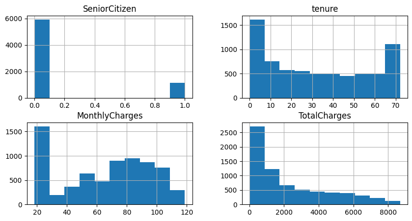

```python
Cu_data.hist(figsize=(10,5))
```

```python
Cu_data.describe()
```

|  | SeniorCitizen | tenure | MonthlyCharges | TotalCharges |
| --- | --- | --- | --- | --- |
| count | 7043.000000 | 7043.000000 | 7043.000000 | 7032.000000 |
| mean | 0.162147 | 32.371149 | 64.761692 | 2283.300441 |
| std | 0.368612 | 24.559481 | 30.090047 | 2266.771362 |
| min | 0.000000 | 0.000000 | 18.250000 | 18.800000 |
| 25% | 0.000000 | 9.000000 | 35.500000 | 401.450000 |
| 50% | 0.000000 | 29.000000 | 70.350000 | 1397.475000 |
| 75% | 0.000000 | 55.000000 | 89.850000 | 3794.737500 |
| max | 1.000000 | 72.000000 | 118.750000 | 8684.800000 |

```python
Cu_data.nunique()
```

```
customerID          7043
gender                 2
SeniorCitizen          2
Partner                2
Dependents             2
tenure                73
PhoneService           2
MultipleLines          3
InternetService        3
OnlineSecurity         3
OnlineBackup           3
DeviceProtection       3
TechSupport            3
StreamingTV            3
StreamingMovies        3
Contract               3
PaperlessBilling       2
PaymentMethod          4
MonthlyCharges      1585
TotalCharges        6530
Churn                  2
dtype: int64
```

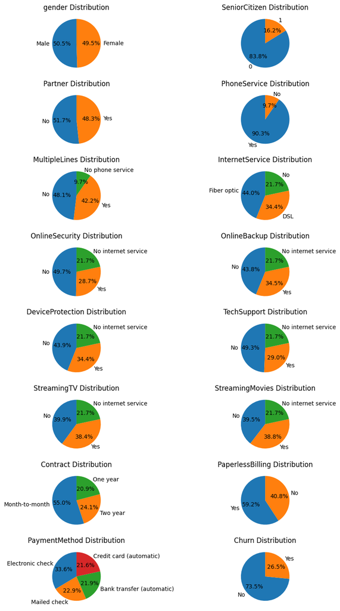

```python
fig = plt.figure(figsize=(10, 15), facecolor='white')

categorical_columns = ['gender', 'SeniorCitizen', 'Partner','PhoneService','MultipleLines','InternetService','OnlineSecurity','OnlineBackup','DeviceProtection','TechSupport','StreamingTV','StreamingMovies','Contract','PaperlessBilling','PaymentMethod','Churn']
unique_categories_dataframes = {}

ncols = 2
nrows = (len(categorical_columns) + ncols - 1) // ncols

# create the subplots
axes = fig.subplots(nrows=nrows, ncols=ncols)

for idx, column in enumerate(categorical_columns):
    row, col = idx // ncols, idx % ncols
    value_counts = Cu_data[column].value_counts(normalize=True)
    labels = value_counts.index
    sizes = value_counts.values

    axes[row, col].pie(sizes, labels=labels, autopct='%1.1f%%', startangle=90)
    axes[row, col].set_title(f'{column} Distribution')

# If there are any empty subplots, remove them
if nrows * ncols > len(categorical_columns):
    for idx in range(len(categorical_columns), nrows * ncols):
        row, col = idx // ncols, idx % ncols
        fig.delaxes(axes[row, col])

plt.tight_layout()
plt.show()
```

```python
# Value counts for each categorical column, presented as a percentage
for column in categorical_columns:
    print(f'Value counts for {column}')
    print(Cu_data[column].value_counts(normalize=True).mul(100).round(1).astype(str) + '%')
    print('---------------------------------------------------')
```

```
Value counts for gender
gender
Male      50.5%
Female    49.5%
Name: proportion, dtype: object
---------------------------------------------------
Value counts for SeniorCitizen
SeniorCitizen
0    83.8%
1    16.2%
Name: proportion, dtype: object
---------------------------------------------------
Value counts for Partner
Partner
No     51.7%
Yes    48.3%
Name: proportion, dtype: object
---------------------------------------------------
Value counts for PhoneService
PhoneService
Yes    90.3%
No      9.7%
Name: proportion, dtype: object
---------------------------------------------------
Value counts for MultipleLines
MultipleLines
No                  48.1%
Yes                 42.2%
No phone service     9.7%
Name: proportion, dtype: object
---------------------------------------------------
Value counts for InternetService
InternetService
Fiber optic    44.0%
DSL            34.4%
No             21.7%
Name: proportion, dtype: object
---------------------------------------------------
Value counts for OnlineSecurity
OnlineSecurity
```

[output cut: 52 more lines]

```
---------------------------------------------------
Value counts for PaymentMethod
PaymentMethod
Electronic check             33.6%
Mailed check                 22.9%
Bank transfer (automatic)    21.9%
Credit card (automatic)      21.6%
Name: proportion, dtype: object
---------------------------------------------------
Value counts for Churn
Churn
No     73.5%
Yes    26.5%
Name: proportion, dtype: object
---------------------------------------------------
```

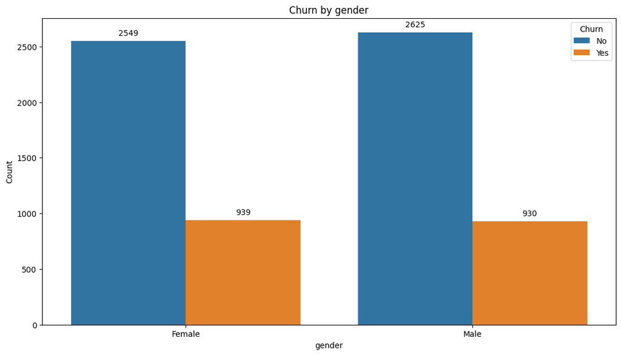

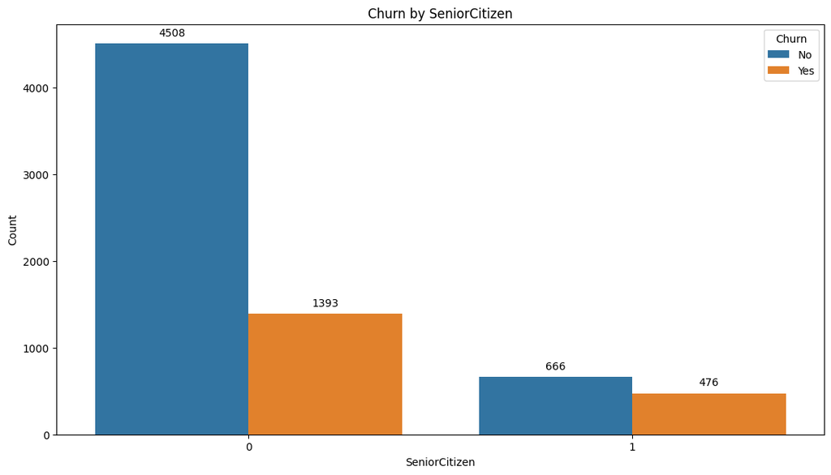

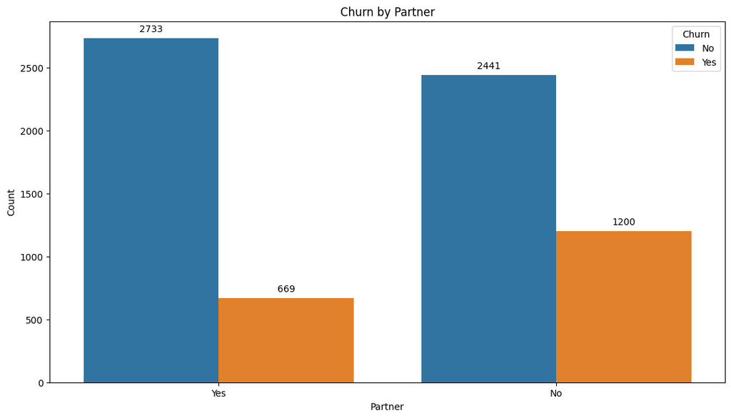

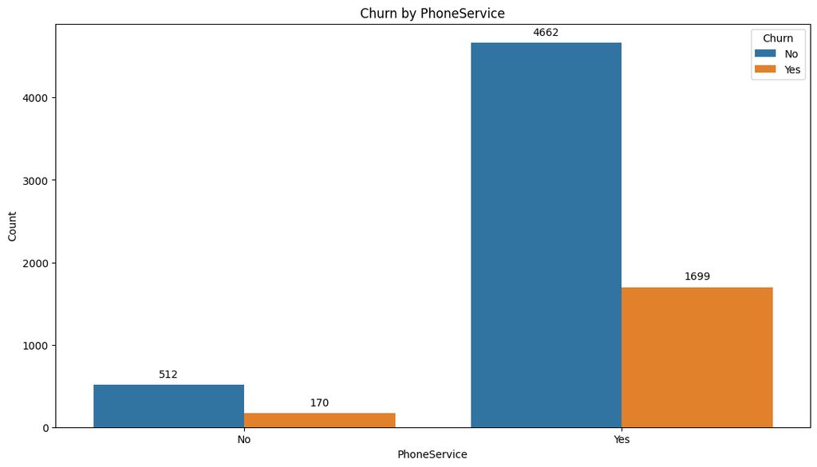

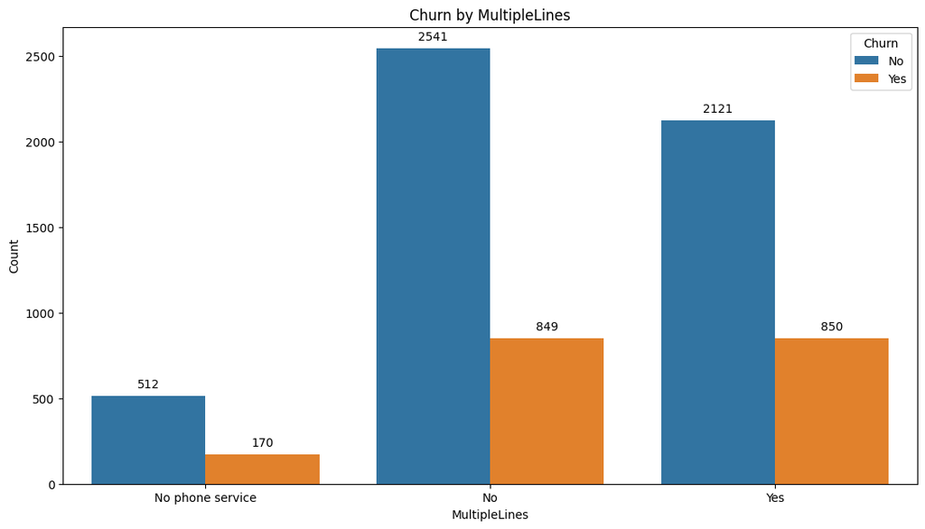

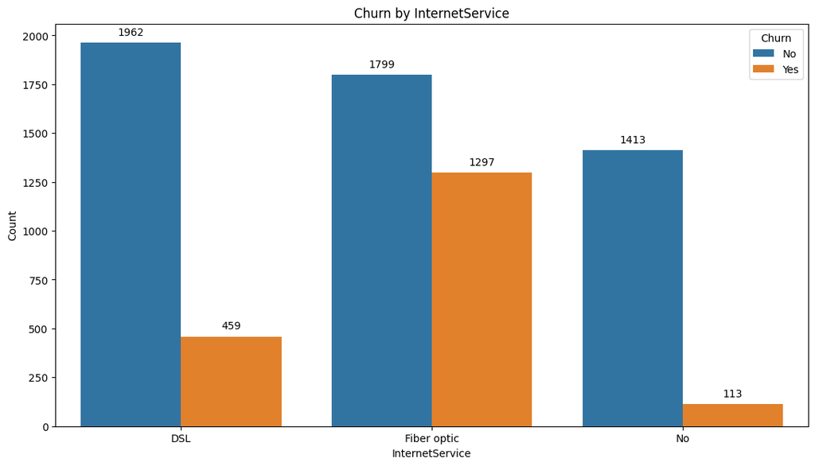

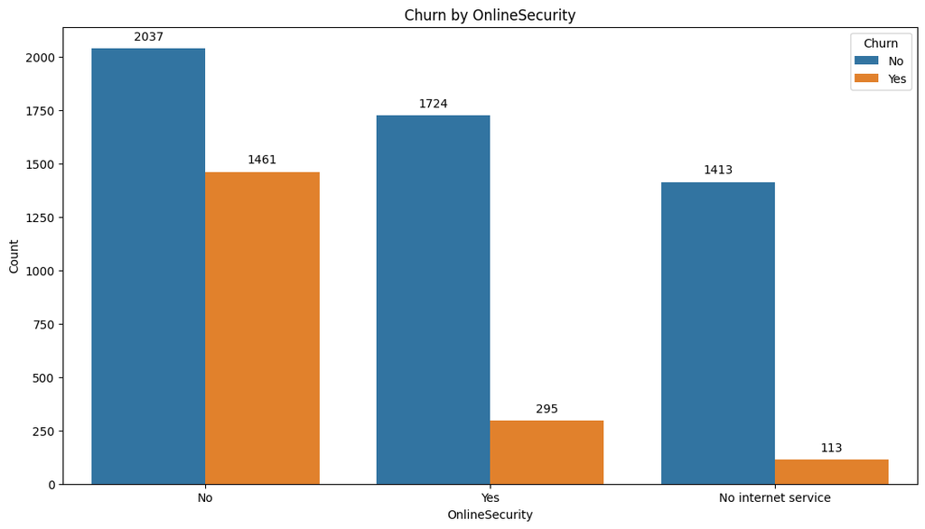

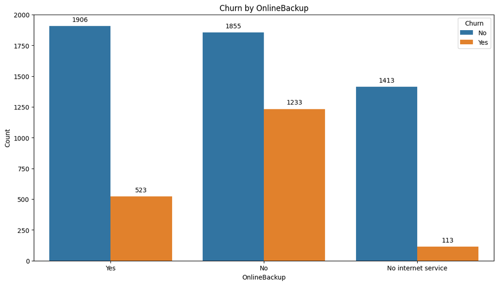

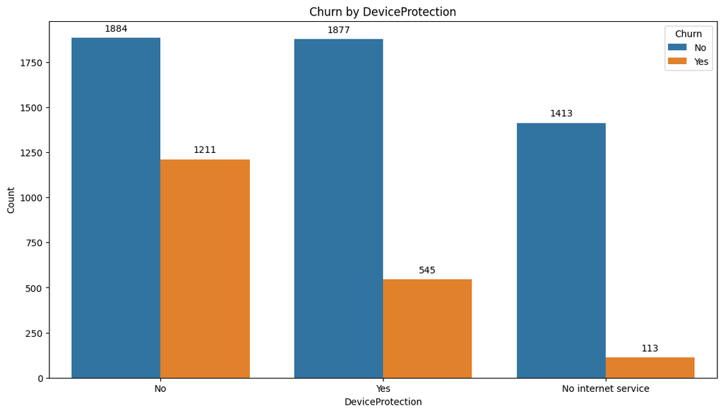

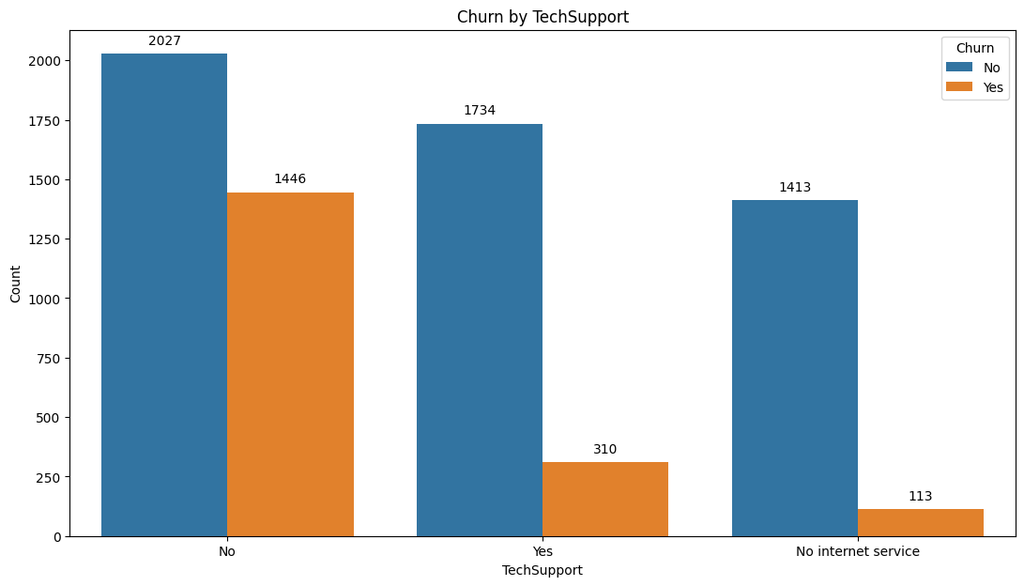

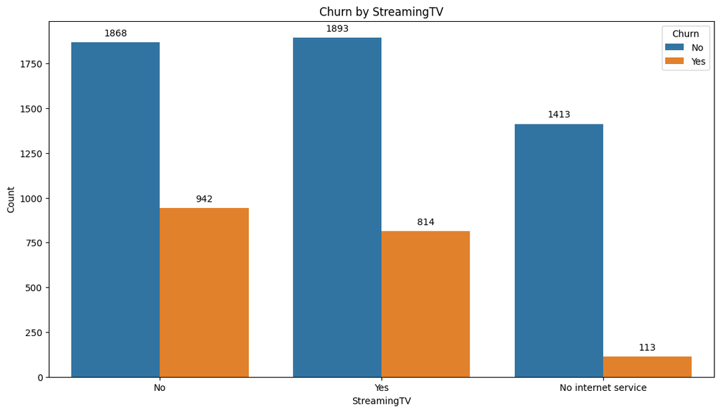

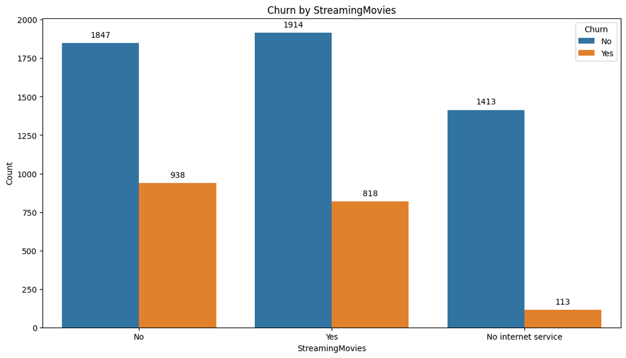

[3 more figures not shown]

```python
# Define a function to create bar plots for each categorical variable
def plot_categorical_churn_relationship(column_name, data):
    plt.figure(figsize=(13, 7))
    ax = sns.countplot(x=column_name, hue='Churn', data=data)
    plt.title(f"Churn by {column_name}")
    plt.xlabel(column_name)
    plt.ylabel('Count')

    # Add count values to the bars
    for p in ax.patches:
        ax.annotate(format(p.get_height(), '.0f'),
                    (p.get_x() + p.get_width() / 2., p.get_height()),
                    ha = 'center', va = 'center',
                    xytext = (0, 10),
                    textcoords = 'offset points')

    plt.show()

# Iterate through categorical_columns and create bar plots for each variable
for column in categorical_columns[:-1]:  # Exclude 'Churn' from the list
    plot_categorical_churn_relationship(column, Cu_data)
```

```python
# Display Pivot table to dataframe group by churm for each categorical column, present as a percentage
for column in categorical_columns[:-1]:  # Exclude 'Churn' from the list
    print(f'Pivot table for {column}')
    display(pd.pivot_table(Cu_data, index='Churn', columns=column, aggfunc='size').apply(lambda x: x / x.sum() * 100, axis=1).round(1).astype(str) + '%')
    print('---------------------------------------------------')
```

```
Pivot table for gender
```

| gender Churn | Female | Male |
| --- | --- | --- |
| No | 49.3% | 50.7% |
| Yes | 50.2% | 49.8% |

```
---------------------------------------------------
Pivot table for SeniorCitizen
```

| SeniorCitizen Churn | 0 | 1 |
| --- | --- | --- |
| No | 87.1% | 12.9% |
| Yes | 74.5% | 25.5% |

```
---------------------------------------------------
Pivot table for Partner
```

| Partner Churn | No | Yes |
| --- | --- | --- |
| No | 47.2% | 52.8% |
| Yes | 64.2% | 35.8% |

```
---------------------------------------------------
Pivot table for PhoneService
```

| PhoneService Churn | No | Yes |
| --- | --- | --- |
| No | 9.9% | 90.1% |
| Yes | 9.1% | 90.9% |

```
---------------------------------------------------
Pivot table for MultipleLines
```

| MultipleLines Churn | No | No phone service | Yes |
| --- | --- | --- | --- |
| No | 49.1% | 9.9% | 41.0% |
| Yes | 45.4% | 9.1% | 45.5% |

```
---------------------------------------------------
Pivot table for InternetService
```

| InternetService Churn | DSL | Fiber optic | No |
| --- | --- | --- | --- |
| No | 37.9% | 34.8% | 27.3% |
| Yes | 24.6% | 69.4% | 6.0% |

```
---------------------------------------------------
Pivot table for OnlineSecurity
```

| OnlineSecurity Churn | No | No internet service | Yes |
| --- | --- | --- | --- |
| No | 39.4% | 27.3% | 33.3% |
| Yes | 78.2% | 6.0% | 15.8% |

```
---------------------------------------------------
Pivot table for OnlineBackup
```

| OnlineBackup Churn | No | No internet service | Yes |
| --- | --- | --- | --- |
| No | 35.9% | 27.3% | 36.8% |
| Yes | 66.0% | 6.0% | 28.0% |

```
---------------------------------------------------
Pivot table for DeviceProtection
```

| DeviceProtection Churn | No | No internet service | Yes |
| --- | --- | --- | --- |
| No | 36.4% | 27.3% | 36.3% |
| Yes | 64.8% | 6.0% | 29.2% |

```
---------------------------------------------------
Pivot table for TechSupport
```

| TechSupport Churn | No | No internet service | Yes |
| --- | --- | --- | --- |
| No | 39.2% | 27.3% | 33.5% |
| Yes | 77.4% | 6.0% | 16.6% |

```
---------------------------------------------------
Pivot table for StreamingTV
```

| StreamingTV Churn | No | No internet service | Yes |
| --- | --- | --- | --- |
| No | 36.1% | 27.3% | 36.6% |
| Yes | 50.4% | 6.0% | 43.6% |

```
---------------------------------------------------
Pivot table for StreamingMovies
```

| StreamingMovies Churn | No | No internet service | Yes |
| --- | --- | --- | --- |
| No | 35.7% | 27.3% | 37.0% |
| Yes | 50.2% | 6.0% | 43.8% |

```
---------------------------------------------------
Pivot table for Contract
```

| Contract Churn | Month-to-month | One year | Two year |
| --- | --- | --- | --- |
| No | 42.9% | 25.3% | 31.8% |
| Yes | 88.6% | 8.9% | 2.6% |

```
---------------------------------------------------
Pivot table for PaperlessBilling
```

| PaperlessBilling Churn | No | Yes |
| --- | --- | --- |
| No | 46.4% | 53.6% |
| Yes | 25.1% | 74.9% |

```
---------------------------------------------------
Pivot table for PaymentMethod
```

| PaymentMethod Churn | Bank transfer (automatic) | Credit card (automatic) | Electronic check | Mailed check |
| --- | --- | --- | --- | --- |
| No | 24.9% | 24.9% | 25.0% | 25.2% |
| Yes | 13.8% | 12.4% | 57.3% | 16.5% |

The majortity of customers are not senior citizens.

Senior citizens may be more likely to churn compared to non-senior citizens.

Customers who has Internet service more likely to churn.

Month-to-month contract, using Electronic check, not using Online serves customers, the churn rate is higher.

1 - 2 year contract having lower churn rate.

As long as customer do not pay with electronic checks, customer churn rates drop.

```python
# Create a box plot for MonthlyCharges and Churn
Charges_fig = make_subplots(rows=1, cols=1)
Charges_fig.add_trace(
    go.Box(
        x=  Cu_data['Churn'],
        y = Cu_data['MonthlyCharges'],
    ),
    row=1, col=1
)

# label all statics
Charges_fig.update_layout(height=500, width=800, title_text="Monthly Charges by Churn") # Update the layout
```

Customers who churned tend to have higher median monthly charges (79.65) compared to those who did not churn (64.425). This means **higher monthly charges may be a contributing factor to customer churn**.

The IQR for customers who churned is narrower than for customers who did not churn. This indicates that the monthly charges for **customers who churned are more concentrated in a higher price range**, while the charges for customers who did not churn are more spread out across different price points.

Both groups have a similar maximum monthly charge, but the minimum monthly charge for customers who did not churn is slightly lower than that for customers who churned. This may indicate that **customers with lower monthly charges are less likely to churn**.

### Now, Let's move on to Feature Enginnering

```python
Processing_data = Cu_data.copy()

Processing_data.isnull().sum()
```

```
customerID           0
gender               0
SeniorCitizen        0
Partner              0
Dependents           0
tenure               0
PhoneService         0
MultipleLines        0
InternetService      0
OnlineSecurity       0
OnlineBackup         0
DeviceProtection     0
TechSupport          0
StreamingTV          0
StreamingMovies      0
Contract             0
PaperlessBilling     0
PaymentMethod        0
MonthlyCharges       0
TotalCharges        11
Churn                0
dtype: int64
```

```python
#Fill in missing values for 'TotalCharges' with the main
Processing_data['TotalCharges'] = Processing_data['TotalCharges'].fillna(Processing_data['TotalCharges'].mean())
```

### Tenure Group

This can help reveal patterns related to customer loyalty and the likelihood of churn based on the length of their relationship with the company.

### Combine Services

Identify patterns in customer preferences for bundled services and their impact on churn.

### Total Services

Identify if customers with more services are less likely to churn

```python
#Create a new categorical feature called 'TenureGroup' by bucketing the 'tenure' variable into different groups (e.g., '0-12 months', '13-24 months', '25-36 months', '37-48 months', '47-60 months', > 60 months).
Processing_data['TenureGroup'] = pd.cut(Processing_data['tenure'], bins=[-1,12,24,36,48,60,72], labels=['0-1 Year', '1-2 Years', '2-3 Years', '3-4 Years', '4-5 Years', '> 5 Years'])
#Create new binary features indicating whether the customer has specific combinations of services, such as 'PhoneAndInternet'
Processing_data['PhoneAndInternet'] = (Processing_data['PhoneService'] == 'Yes') & (Processing_data['InternetService'] != 'No')
#Create new binary features indicating whether the customer has specific combinations of services, such as 'TechSupportAndInternet'
Processing_data['TechSupportANDInternet'] = (Processing_data['TechSupport'] == 'Yes') & (Processing_data['InternetService'] != 'No')
#Create new binary features indicating whether the customer has specific combinations of services, such as 'SecurityAndInternet'
Processing_data['SecurityANDInternet'] = (Processing_data['OnlineSecurity'] == 'Yes') & (Processing_data['InternetService'] != 'No')
#Create new binary features indicating whether the customer has specific combinations of services, such as 'BackupAndInternet'
Processing_data['BackupANDInternet'] = (Processing_data['OnlineBackup'] == 'Yes') & (Processing_data['InternetService'] != 'No')
#Create new binary features indicating whether the customer has specific combinations of services, such as 'DeviceProtectionAndInternet'
Processing_data['DeviceProtectionANDInternet'] = (Processing_data['DeviceProtection'] == 'Yes') & (Processing_data['InternetService'] != 'No')
#Create new binary features indicating whether the customer has specific combinations of services, such as 'StreamingTV,StramingMoviesAndInternet'
Processing_data['StreamingTV_StramingMoviesANDInternet'] = (Processing_data['StreamingTV'] == 'Yes') & (Processing_data['StreamingMovies'] == 'Yes') & (Processing_data['InternetService'] != 'No')
#Create new binary features indicating whether the customer has specific combinations of services, such as 'BackupAndInternet'
Processing_data['BackupANDInternet'] = (Processing_data['OnlineBackup'] == 'Yes') & (Processing_data['InternetService'] != 'No')
```

```python
#Create a new feature called 'TotalServices' that counts the number of services a customer has subscribed to (e.g., phone, internet, online security, online backup, device protection, tech support, streaming TV, and streaming movies).
Processing_data['TotalServices'] = Processing_data[['PhoneService', 'InternetService', 'OnlineSecurity', 'OnlineBackup', 'DeviceProtection', 'TechSupport', 'StreamingTV', 'StreamingMovies']].replace({'Yes': 1, 'No': 0, 'No internet service': 0, 'DSL': 1, 'Fiber optic': 1}).astype(int).sum(axis=1)
```

```python
#Create a feature indicating whether a customer is a senior citizen with tech support or a non-senior citizen with tech support.
Processing_data['SeniorCitizenWithTechSupport'] = (Processing_data['SeniorCitizen'] == 1) & (Processing_data['TechSupport'] == 'Yes')
```

```python
Processing_data.isnull().sum()
```

```
customerID                               0
gender                                   0
SeniorCitizen                            0
Partner                                  0
Dependents                               0
tenure                                   0
PhoneService                             0
MultipleLines                            0
InternetService                          0
OnlineSecurity                           0
OnlineBackup                             0
DeviceProtection                         0
TechSupport                              0
StreamingTV                              0
StreamingMovies                          0
Contract                                 0
PaperlessBilling                         0
PaymentMethod                            0
MonthlyCharges                           0
TotalCharges                             0
Churn                                    0
TenureGroup                              0
PhoneAndInternet                         0
TechSupportANDInternet                   0
SecurityANDInternet                      0
BackupANDInternet                        0
DeviceProtectionANDInternet              0
StreamingTV_StramingMoviesANDInternet    0
TotalServices                            0
SeniorCitizenWithTechSupport             0
dtype: int64
```

```python
Processing_data.head()
```

|  | customerID | gender | SeniorCitizen | Partner | Dependents | tenure | PhoneService | MultipleLines | InternetService | OnlineSecurity | ... | Churn | TenureGroup | PhoneAndInternet | TechSupportANDInternet | SecurityANDInternet | BackupANDInternet | DeviceProtectionANDInternet | StreamingTV_StramingMoviesANDInternet | TotalServices | SeniorCitizenWithTechSupport |
| --- | --- | --- | --- | --- | --- | --- | --- | --- | --- | --- | --- | --- | --- | --- | --- | --- | --- | --- | --- | --- | --- |
| 0 | 7590-VHVEG | Female | 0 | Yes | No | 1 | No | No phone service | DSL | No | ... | No | 0-1 Year | False | False | False | True | False | False | 2 | False |
| 1 | 5575-GNVDE | Male | 0 | No | No | 34 | Yes | No | DSL | Yes | ... | No | 2-3 Years | True | False | True | False | True | False | 4 | False |
| 2 | 3668-QPYBK | Male | 0 | No | No | 2 | Yes | No | DSL | Yes | ... | Yes | 0-1 Year | True | False | True | True | False | False | 4 | False |
| 3 | 7795-CFOCW | Male | 0 | No | No | 45 | No | No phone service | DSL | Yes | ... | No | 3-4 Years | False | True | True | False | True | False | 4 | False |
| 4 | 9237-HQITU | Female | 0 | No | No | 2 | Yes | No | Fiber optic | No | ... | Yes | 0-1 Year | True | False | False | False | False | False | 2 | False |

5 rows × 30 columns

```python
TenureGroup_Churn_Histfig = px.histogram(Processing_data, x='TenureGroup', color='Churn', barmode='group', title='Tenure Group Churn')
TenureGroup_Churn_Histfig.update_layout(width=800, height=500)
```

```python
# Pivot table for TenureGroup by churm, dont't need percentage
print(pd.pivot_table(Processing_data, index='Churn', columns='TenureGroup', aggfunc='size'))
```

```
TenureGroup  0-1 Year  1-2 Years  2-3 Years  3-4 Years  4-5 Years  > 5 Years
Churn
No               1149        730        652        617        712       1314
Yes              1037        294        180        145        120         93
```

0-1 year customers seem to be more likely to churn.

```python
#Create a Historgram for 'TechSupportANDInternet' and 'Churn'
TechSupportANDInternet_Churn_Histfig = px.histogram(Processing_data, x='TechSupportANDInternet', color='Churn', barmode='group', title='Tech Support AND Internet Churn')
TechSupportANDInternet_Churn_Histfig.update_layout(xaxis_title='Tech Support AND Internet', yaxis_title='Count',height=500, width=800)
TechSupportANDInternet_Churn_Histfig
```

```python
#Create a Historgram for 'SecurityANDInternet' and 'Churn'
SecurityANDInternet_Churn_Histfig = px.histogram(Processing_data, x='SecurityANDInternet', color='Churn', barmode='group', title='Security AND Internet Churn')
SecurityANDInternet_Churn_Histfig.update_layout(xaxis_title='Security AND Internet', yaxis_title='Count',height=500, width=800)
SecurityANDInternet_Churn_Histfig
```

```python
#Create a Historgram for 'BackupANDInternet' and 'Churn'
BackupANDInternet_Churn_Histfig = px.histogram(Processing_data, x='BackupANDInternet', color='Churn', barmode='group', title='Backup AND Internet Churn')
BackupANDInternet_Churn_Histfig.update_layout(xaxis_title='Backup AND Internet', yaxis_title='Count',height=500, width=800)
BackupANDInternet_Churn_Histfig
```

```python
#Create a Historgram for 'StreamingTV_StramingMoviesANDInternet' and 'Churn'
StreamingTV_StramingMoviesANDInternet_Churn_Histfig = px.histogram(Processing_data, x='StreamingTV_StramingMoviesANDInternet', color='Churn', barmode='group', title='Streaming TV,Straming Movies AND Internet Churn')
StreamingTV_StramingMoviesANDInternet_Churn_Histfig.update_layout(xaxis_title='Streaming TV,Straming Movies AND Internet', yaxis_title='Count',height=500, width=800)
StreamingTV_StramingMoviesANDInternet_Churn_Histfig
```

```python
#Create a Historgram for 'TotalServices' and 'Churn'
TotalServices_Churn_Histfig = px.histogram(Processing_data, x='TotalServices', color='Churn', barmode='group', title='Total Services Churn')
TotalServices_Churn_Histfig.update_layout(xaxis_title='Total Services', yaxis_title='Count',height=500, width=800)
TotalServices_Churn_Histfig
```

```python
# Pivot table for TotalServices by churm, dont't need percentage
print(pd.pivot_table(Processing_data, index='Churn', columns='TotalServices', aggfunc='size'))
```

```
TotalServices     1    2    3    4    5    6    7    8
Churn
No             1458  352  563  680  773  645  459  244
Yes             148  375  433  361  289  182   66   15
```

Those customers who have Internet service and have TechSupport or Security or Backup service, they have lower churn rate.

**Higher churn rate** for customers who have **Streaming Services and Internet Services** at the same time

```python
train_data = Processing_data.copy()
```

```python
from sklearn.preprocessing import LabelEncoder

# Instantiate the LabelEncoder
encoder = LabelEncoder()

# Iterate through binary categorical columns and apply label encoding
binary_categorical_columns = [
    'gender', 'Partner', 'Dependents', 'PhoneService', 'PaperlessBilling', 'Churn'
]

for col in binary_categorical_columns:
    train_data[col] = encoder.fit_transform(train_data[col])
```

```python
# Iterate through multi-category nominal columns and apply one-hot encoding
multi_category_columns = [
    'MultipleLines', 'InternetService', 'OnlineSecurity', 'OnlineBackup',
    'DeviceProtection', 'TechSupport', 'StreamingTV', 'StreamingMovies',
    'Contract', 'PaymentMethod', 'TenureGroup'
]

# Apply one-hot encoding and concatenate with the original dataframe
train_data = pd.get_dummies(train_data, columns=multi_category_columns, drop_first=True)
```

```python
train_data.drop('customerID', axis=1, inplace=True)
```

```python
train_data.info()
```

```
<class 'pandas.core.frame.DataFrame'>
RangeIndex: 7043 entries, 0 to 7042
Data columns (total 44 columns):
 #   Column                                 Non-Null Count  Dtype
---  ------                                 --------------  -----
 0   gender                                 7043 non-null   int32
 1   SeniorCitizen                          7043 non-null   int64
 2   Partner                                7043 non-null   int32
 3   Dependents                             7043 non-null   int32
 4   tenure                                 7043 non-null   int64
 5   PhoneService                           7043 non-null   int32
 6   PaperlessBilling                       7043 non-null   int32
 7   MonthlyCharges                         7043 non-null   float64
 8   TotalCharges                           7043 non-null   float64
 9   Churn                                  7043 non-null   int32
```

[output cut: 36 more lines]

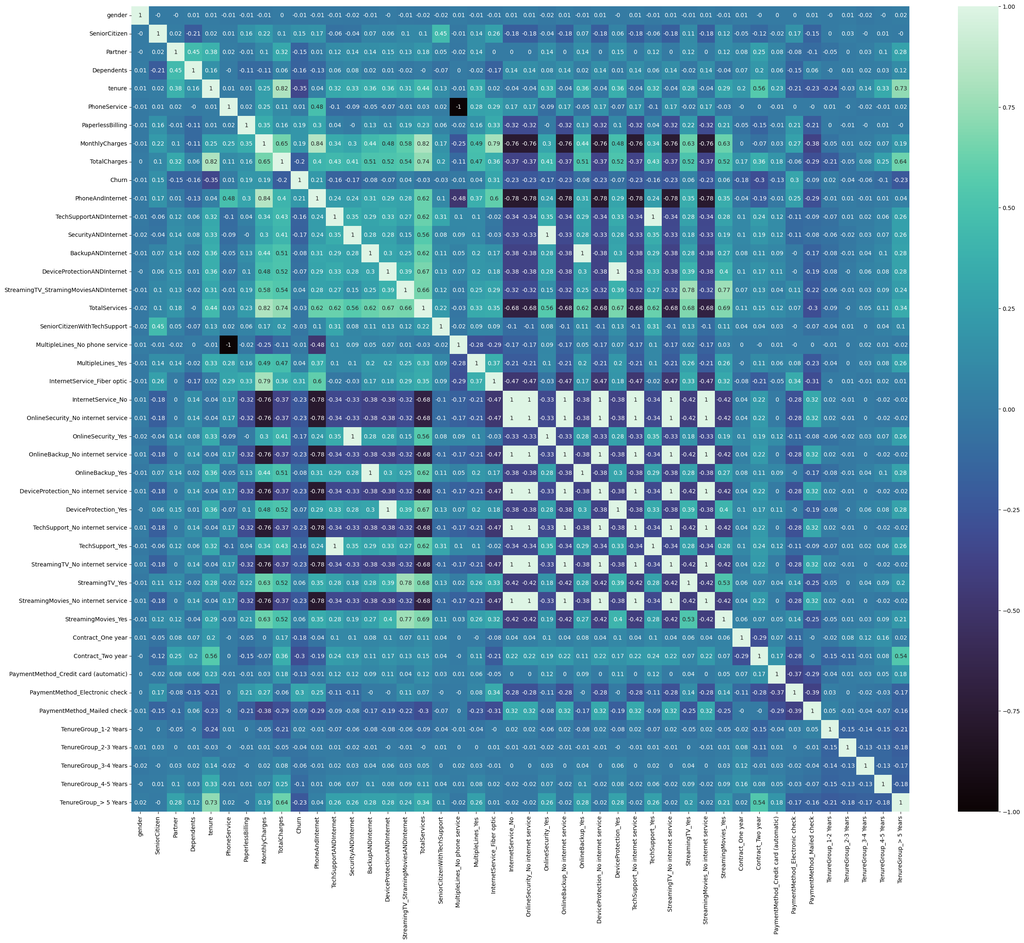

```python
train_data_corr = train_data.corr()
plt.figure(figsize=(30, 25))
sns.heatmap(round(train_data_corr, 2), annot=True, cmap="mako")
```

```python
churn_corr = train_data_corr["Churn"].sort_values(ascending=False)
churn_corr
```

```
Churn                                    1.000000
InternetService_Fiber optic              0.308020
PaymentMethod_Electronic check           0.301919
PhoneAndInternet                         0.209988
MonthlyCharges                           0.193356
PaperlessBilling                         0.191825
SeniorCitizen                            0.150889
StreamingTV_Yes                          0.063228
StreamingMovies_Yes                      0.061382
StreamingTV_StramingMoviesANDInternet    0.040441
MultipleLines_Yes                        0.040102
TenureGroup_1-2 Years                    0.020308
PhoneService                             0.011942
gender                                  -0.008612
MultipleLines_No phone service          -0.011942
SeniorCitizenWithTechSupport            -0.030692
TotalServices                           -0.030765
TenureGroup_2-3 Years                   -0.040637
TenureGroup_3-4 Years                   -0.059229
DeviceProtection_Yes                    -0.066160
DeviceProtectionANDInternet             -0.066160
BackupANDInternet                       -0.082255
OnlineBackup_Yes                        -0.082255
PaymentMethod_Mailed check              -0.091683
TenureGroup_4-5 Years                   -0.100416
PaymentMethod_Credit card (automatic)   -0.134302
Partner                                 -0.150448
Dependents                              -0.164221
TechSupportANDInternet                  -0.164674
TechSupport_Yes                         -0.164674
SecurityANDInternet                     -0.171226
OnlineSecurity_Yes                      -0.171226
Contract_One year                       -0.177820
TotalCharges                            -0.199428
TenureGroup_> 5 Years                   -0.225500
StreamingMovies_No internet service     -0.227890
StreamingTV_No internet service         -0.227890
TechSupport_No internet service         -0.227890
DeviceProtection_No internet service    -0.227890
OnlineBackup_No internet service        -0.227890
InternetService_No                      -0.227890
OnlineSecurity_No internet service      -0.227890
Contract_Two year                       -0.302253
tenure                                  -0.352229
Name: Churn, dtype: float64
```

```python
# Set the correlation threshold
threshold = 0.2

# Filter the not very weak correlated features
not_weak_corr = churn_corr[(churn_corr >= threshold) | (churn_corr <= -threshold)]

# Create a DataFrame to display the results
not_weak_corr = pd.DataFrame(not_weak_corr, columns=['Churn']).reset_index()
not_weak_corr.columns = ['Feature', 'Correlation']

# Display the DataFrame
display(not_weak_corr)
```

|  | Feature | Correlation |
| --- | --- | --- |
| 0 | Churn | 1.000000 |
| 1 | InternetService_Fiber optic | 0.308020 |
| 2 | PaymentMethod_Electronic check | 0.301919 |
| 3 | PhoneAndInternet | 0.209988 |
| 4 | TenureGroup_> 5 Years | -0.225500 |
| 5 | StreamingMovies_No internet service | -0.227890 |
| 6 | StreamingTV_No internet service | -0.227890 |
| 7 | TechSupport_No internet service | -0.227890 |
| 8 | DeviceProtection_No internet service | -0.227890 |
| 9 | OnlineBackup_No internet service | -0.227890 |
| 10 | InternetService_No | -0.227890 |
| 11 | OnlineSecurity_No internet service | -0.227890 |
| 12 | Contract_Two year | -0.302253 |
| 13 | tenure | -0.352229 |

### Positive correlations:

Features like 'InternetService_Fiber optic', 'PaymentMethod_Electronic check', 'PhoneAndInternet', 'MonthlyCharges', and 'PaperlessBilling' show a positive correlation with Churn. This indicates that customers with **these characteristics are more likely to churn**.

### Negative correlations:

Features like 'tenure', 'Contract_Two year', and various services with 'No internet service' show strong negative correlations with Churn. This suggests that customers with **longer tenures, two-year contracts, or without internet services are less likely to churn.**

### Demographic factors:

'SeniorCitizen' has a positive correlation with Churn, indicating that senior citizens are more likely to churn compared to non-senior citizens. In contrast, 'Partner' and 'Dependents' have negative correlations, suggesting that **customers with partners or dependents are less likely to churn.**

### Support services:

Features such as 'TechSupportANDInternet', 'TechSupport_Yes', 'OnlineSecurity_Yes', and 'SecurityANDInternet' show negative correlations with Churn, indicating that **customers who have signed up for tech support or online security services are less likely to churn.**

### Contract and Tenure:

Longer contracts ('Contract_One year' and 'Contract_Two year') and higher tenure groups ('TenureGroup_4-5 Years' and 'TenureGroup_> 5 Years') are negatively correlated with Churn, suggesting that **customers with longer commitments to the company are less likely to churn.**

### Now that we have a clear understanding of the dataset, let's start selecting features to build an ML model for predicting customer churn.

In corr, those variable are potential choices, but let's try more feature selection techniques, like Univariate, RFE, etc.

```python
# Univariate feature selection
from sklearn.feature_selection import SelectKBest, chi2
from sklearn.model_selection import cross_val_score
from sklearn.linear_model import LogisticRegression

# Define your features (X) and target (y)
Univariate_X = train_data.drop(columns=['Churn'])
Univariate_y = train_data['Churn']


# Initialize the model you want to use (e.g., Logistic Regression)
model = LogisticRegression(solver='liblinear', random_state=42)

# Loop through different k values and find the optimal one
best_k = 0
best_score = 0
for k in range(1, Univariate_X.shape[1] + 1):
    selector = SelectKBest(chi2, k=k)
    X_new = selector.fit_transform(Univariate_X, Univariate_y)
    scores = cross_val_score(model, X_new, Univariate_y, cv=5)  # Using 5-fold cross-validation
    mean_score = scores.mean()

    if mean_score > best_score:
        best_score = mean_score
        best_k = k

print("Best k:", best_k)

# Instantiate the SelectKBest object
k = best_k
selector = SelectKBest(chi2, k=k)

# Fit the selector to your data
selector.fit(Univariate_X, Univariate_y)

# Get the indices of the top k features
selected_features_indices = selector.get_support(indices=True)

# Get the names of the selected features
selected_features = Univariate_X.columns[selected_features_indices]

print("Selected features:")
print(selected_features)
```

```
Best k: 34
Selected features:
Index(['SeniorCitizen', 'Partner', 'Dependents', 'tenure', 'PaperlessBilling',
       'MonthlyCharges', 'TotalCharges', 'PhoneAndInternet',
       'TechSupportANDInternet', 'SecurityANDInternet', 'BackupANDInternet',
       'DeviceProtectionANDInternet', 'InternetService_Fiber optic',
       'InternetService_No', 'OnlineSecurity_No internet service',
       'OnlineSecurity_Yes', 'OnlineBackup_No internet service',
       'OnlineBackup_Yes', 'DeviceProtection_No internet service',
       'DeviceProtection_Yes', 'TechSupport_No internet service',
       'TechSupport_Yes', 'StreamingTV_No internet service', 'StreamingTV_Yes',
       'StreamingMovies_No internet service', 'StreamingMovies_Yes',
       'Contract_One year', 'Contract_Two year',
       'PaymentMethod_Credit card (automatic)',
       'PaymentMethod_Electronic check', 'PaymentMethod_Mailed check',
       'TenureGroup_3-4 Years', 'TenureGroup_4-5 Years',
       'TenureGroup_> 5 Years'],
      dtype='object')
```

```python
# RFE feature selection

from sklearn.model_selection import StratifiedKFold
from sklearn.feature_selection import RFECV
from sklearn.preprocessing import StandardScaler

numeric_columns = ['tenure', 'MonthlyCharges', 'TotalCharges', 'TotalServices']

# Create a StandardScaler instance
scaler = StandardScaler()

# Fit and transform the numeric columns
train_data[numeric_columns] = scaler.fit_transform(train_data[numeric_columns])

# Create an estimator (Logistic Regression, for example)
estimator = LogisticRegression(solver='liblinear', random_state=42)

# Create a StratifiedKFold instance for cross-validation
cv = StratifiedKFold(n_splits=5)

# Create an RFECV instance with the estimator and cross-validator
rfe = RFECV(estimator, step=1, cv=cv, scoring='accuracy')

# Prepare the target variable and features
RFE_X = train_data.drop('Churn', axis=1)
RFE_y = train_data['Churn']

# Fit the RFE selector to the data
rfe.fit(RFE_X, RFE_y)

# Print the optimal number of features
print(f"Optimal number of features: {rfe.n_features_}")

# Get a boolean mask of the selected features
selected_features = rfe.support_

# Print the names of the selected features
print("Selected features:")
print(RFE_X.columns[selected_features])
```

```
Optimal number of features: 43
Selected features:
Index(['gender', 'SeniorCitizen', 'Partner', 'Dependents', 'tenure',
       'PhoneService', 'PaperlessBilling', 'MonthlyCharges', 'TotalCharges',
       'PhoneAndInternet', 'TechSupportANDInternet', 'SecurityANDInternet',
       'BackupANDInternet', 'DeviceProtectionANDInternet',
       'StreamingTV_StramingMoviesANDInternet', 'TotalServices',
       'SeniorCitizenWithTechSupport', 'MultipleLines_No phone service',
       'MultipleLines_Yes', 'InternetService_Fiber optic',
       'InternetService_No', 'OnlineSecurity_No internet service',
       'OnlineSecurity_Yes', 'OnlineBackup_No internet service',
       'OnlineBackup_Yes', 'DeviceProtection_No internet service',
       'DeviceProtection_Yes', 'TechSupport_No internet service',
       'TechSupport_Yes', 'StreamingTV_No internet service', 'StreamingTV_Yes',
       'StreamingMovies_No internet service', 'StreamingMovies_Yes',
       'Contract_One year', 'Contract_Two year',
       'PaymentMethod_Credit card (automatic)',
       'PaymentMethod_Electronic check', 'PaymentMethod_Mailed check',
       'TenureGroup_1-2 Years', 'TenureGroup_2-3 Years',
       'TenureGroup_3-4 Years', 'TenureGroup_4-5 Years',
       'TenureGroup_> 5 Years'],
      dtype='object')
```

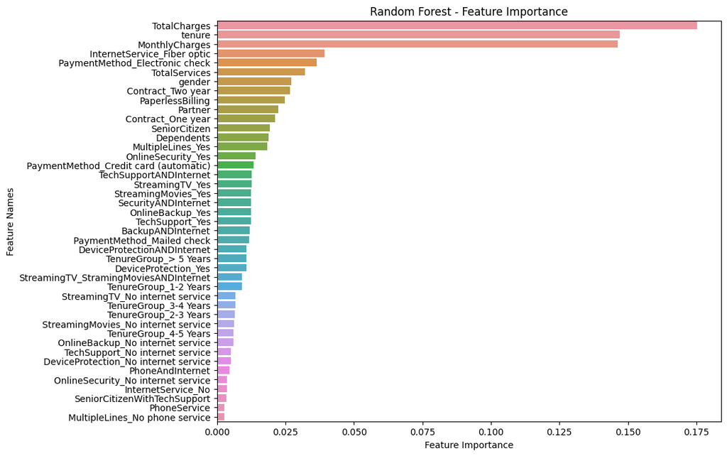

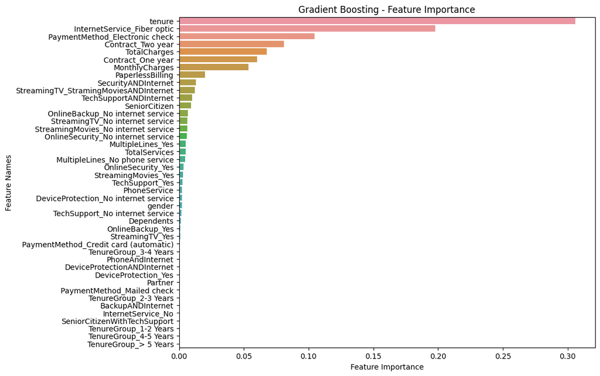

```python
# Tree-based feature selection
from sklearn.ensemble import RandomForestClassifier, GradientBoostingClassifier

Tree_X = train_data.drop('Churn', axis=1)
Tree_y = train_data['Churn']

rf_model = RandomForestClassifier(random_state=42)
rf_model.fit(Tree_X, Tree_y)

gb_model = GradientBoostingClassifier(random_state=42)
gb_model.fit(Tree_X, Tree_y)

def plot_feature_importance(importance, names, model_type):
    feature_importance = np.array(importance)
    feature_names = np.array(names)

    data={'feature_names':feature_names,'feature_importance':feature_importance}
    fi_df = pd.DataFrame(data)

    fi_df.sort_values(by=['feature_importance'], ascending=False,inplace=True)

    plt.figure(figsize=(10,8))
    sns.barplot(x=fi_df['feature_importance'], y=fi_df['feature_names'])
    plt.title(model_type + ' - Feature Importance')
    plt.xlabel('Feature Importance')
    plt.ylabel('Feature Names')

plot_feature_importance(rf_model.feature_importances_, Tree_X.columns, 'Random Forest')
plot_feature_importance(gb_model.feature_importances_, Tree_X.columns, 'Gradient Boosting')
```

```python
rf_importance = rf_model.feature_importances_
gb_importance = gb_model.feature_importances_

feature_importance_df = pd.DataFrame({"Feature": Tree_X.columns, "RandomForest": rf_importance, "GradientBoosting": gb_importance})

feature_importance_df["AverageImportance"] = (feature_importance_df["RandomForest"] + feature_importance_df["GradientBoosting"]) / 2

feature_importance_df = feature_importance_df.sort_values(by="AverageImportance", ascending=False)

feature_importance_df
```

|  | Feature | RandomForest | GradientBoosting | AverageImportance |
| --- | --- | --- | --- | --- |
| 4 | tenure | 0.146932 | 0.305864 | 0.226398 |
| 8 | TotalCharges | 0.175185 | 0.067884 | 0.121535 |
| 19 | InternetService_Fiber optic | 0.039259 | 0.197757 | 0.118508 |
| 7 | MonthlyCharges | 0.146213 | 0.053500 | 0.099857 |
| 36 | PaymentMethod_Electronic check | 0.036327 | 0.104751 | 0.070539 |
| 34 | Contract_Two year | 0.026644 | 0.081031 | 0.053837 |
| 33 | Contract_One year | 0.021324 | 0.060237 | 0.040780 |
| 6 | PaperlessBilling | 0.024832 | 0.019844 | 0.022338 |
| 15 | TotalServices | 0.032070 | 0.005089 | 0.018580 |
| 0 | gender | 0.027219 | 0.002148 | 0.014683 |
| 1 | SeniorCitizen | 0.019274 | 0.009157 | 0.014215 |
| 11 | SecurityANDInternet | 0.012501 | 0.012825 | 0.012663 |
| 18 | MultipleLines_Yes | 0.018330 | 0.005119 | 0.011724 |
| 10 | TechSupportANDInternet | 0.012577 | 0.010081 | 0.011329 |
| 2 | Partner | 0.022358 | 0.000213 | 0.011285 |
| 14 | StreamingTV_StramingMoviesANDInternet | 0.009175 | 0.012106 | 0.010640 |
| 3 | Dependents | 0.018790 | 0.001525 | 0.010157 |
| 22 | OnlineSecurity_Yes | 0.014037 | 0.003598 | 0.008817 |
| 32 | StreamingMovies_Yes | 0.012503 | 0.002849 | 0.007676 |
| 28 | TechSupport_Yes | 0.012381 | 0.002751 | 0.007566 |
| 35 | PaymentMethod_Credit card (automatic) | 0.013471 | 0.000712 | 0.007091 |
| 24 | OnlineBackup_Yes | 0.012446 | 0.001159 | 0.006803 |
| 30 | StreamingTV_Yes | 0.012552 | 0.000833 | 0.006692 |
| 29 | StreamingTV_No internet service | 0.006722 | 0.006439 | 0.006580 |
| 23 | OnlineBackup_No internet service | 0.005957 | 0.006966 | 0.006461 |
| 31 | StreamingMovies_No internet service | 0.006214 | 0.006427 | 0.006320 |
| 37 | PaymentMethod_Mailed check | 0.011759 | 0.000200 | 0.005979 |
| 12 | BackupANDInternet | 0.011861 | 0.000051 | 0.005956 |
| 13 | DeviceProtectionANDInternet | 0.010845 | 0.000451 | 0.005648 |
| 26 | DeviceProtection_Yes | 0.010686 | 0.000286 | 0.005486 |
| 42 | TenureGroup_> 5 Years | 0.010762 | 0.000000 | 0.005381 |
| 21 | OnlineSecurity_No internet service | 0.003734 | 0.005805 | 0.004769 |
| 38 | TenureGroup_1-2 Years | 0.009115 | 0.000000 | 0.004558 |
| 40 | TenureGroup_3-4 Years | 0.006664 | 0.000692 | 0.003678 |
| 25 | DeviceProtection_No internet service | 0.005000 | 0.002269 | 0.003634 |
| 17 | MultipleLines_No phone service | 0.002604 | 0.004527 | 0.003565 |
| 27 | TechSupport_No internet service | 0.005010 | 0.001769 | 0.003390 |
| 39 | TenureGroup_2-3 Years | 0.006548 | 0.000165 | 0.003356 |
| 41 | TenureGroup_4-5 Years | 0.005999 | 0.000000 | 0.003000 |
| 5 | PhoneService | 0.002707 | 0.002406 | 0.002556 |
| 9 | PhoneAndInternet | 0.004528 | 0.000513 | 0.002520 |
| 20 | InternetService_No | 0.003556 | 0.000000 | 0.001778 |
| 16 | SeniorCitizenWithTechSupport | 0.003332 | 0.000000 | 0.001666 |

```python
"""
Here are the features we decide to use to build a ML model:

"InternetService_Fiber optic","PaymentMethod_Electronic check","PhoneAndInternet","MonthlyCharges","PaperlessBilling","Dependents","TechSupportANDInternet","TechSupport_Yes","OnlineSecurity_Yes",SecurityANDInternet","Contract_One year","TotalCharges","TenureGroup_> 5 Years","StreamingMovies_No internet service","StreamingTV_No internet service","TechSupport_No internet service","DeviceProtection_No internet service","OnlineBackup_No internet service","InternetService_No","OnlineSecurity_No internet service","Contract_Two year","tenure","Churn"

"""

Select_DATA = train_data[["InternetService_Fiber optic","PaymentMethod_Electronic check","PhoneAndInternet","MonthlyCharges","PaperlessBilling","Dependents","TechSupportANDInternet","TechSupport_Yes",
"OnlineSecurity_Yes","SecurityANDInternet","Contract_One year","TotalCharges","TenureGroup_> 5 Years","StreamingMovies_No internet service","StreamingTV_No internet service","TechSupport_No internet service","DeviceProtection_No internet service",
"OnlineBackup_No internet service","InternetService_No","OnlineSecurity_No internet service","Contract_Two year","tenure","Churn"]].copy()
```

```python
Select_DATA.info()
```

```
<class 'pandas.core.frame.DataFrame'>
RangeIndex: 7043 entries, 0 to 7042
Data columns (total 23 columns):
 #   Column                                Non-Null Count  Dtype
---  ------                                --------------  -----
 0   InternetService_Fiber optic           7043 non-null   bool
 1   PaymentMethod_Electronic check        7043 non-null   bool
 2   PhoneAndInternet                      7043 non-null   bool
 3   MonthlyCharges                        7043 non-null   float64
 4   PaperlessBilling                      7043 non-null   int32
 5   Dependents                            7043 non-null   int32
 6   TechSupportANDInternet                7043 non-null   bool
 7   TechSupport_Yes                       7043 non-null   bool
 8   OnlineSecurity_Yes                    7043 non-null   bool
 9   SecurityANDInternet                   7043 non-null   bool
 10  Contract_One year                     7043 non-null   bool
 11  TotalCharges                          7043 non-null   float64
 12  TenureGroup_> 5 Years                 7043 non-null   bool
 13  StreamingMovies_No internet service   7043 non-null   bool
 14  StreamingTV_No internet service       7043 non-null   bool
 15  TechSupport_No internet service       7043 non-null   bool
 16  DeviceProtection_No internet service  7043 non-null   bool
 17  OnlineBackup_No internet service      7043 non-null   bool
 18  InternetService_No                    7043 non-null   bool
 19  OnlineSecurity_No internet service    7043 non-null   bool
 20  Contract_Two year                     7043 non-null   bool
 21  tenure                                7043 non-null   float64
 22  Churn                                 7043 non-null   int32
dtypes: bool(17), float64(3), int32(3)
memory usage: 364.7 KB
```

```python
from sklearn.model_selection import train_test_split

Training_X = Select_DATA.drop('Churn', axis=1)
Training_y = Select_DATA['Churn']

X_train, X_test, y_train, y_test = train_test_split(Training_X, Training_y, test_size=0.2, random_state=42)

from sklearn.preprocessing import StandardScaler

scaler = StandardScaler()
X_train_scaled = scaler.fit_transform(X_train)
X_test_scaled = scaler.transform(X_test)
```

```python
from sklearn.neighbors import KNeighborsClassifier
from sklearn.svm import SVC
from sklearn.naive_bayes import GaussianNB
from sklearn.tree import DecisionTreeClassifier
from sklearn.ensemble import RandomForestClassifier
from sklearn.linear_model import Perceptron
from sklearn.neural_network import MLPClassifier

models = [
    ('Logistic Regression', LogisticRegression(solver='liblinear')),
    ('KNN', KNeighborsClassifier()),
    ('Support Vector Machines', SVC()),
    ('Naive Bayes', GaussianNB()),
    ('Decision Tree', DecisionTreeClassifier()),
    ('Random Forest', RandomForestClassifier(n_estimators=100)),
    ('Perceptron', Perceptron()),
    ('Artificial Neural Network', MLPClassifier(max_iter=6000))
]
```

```
Logistic Regression: 0.797 (0.008)
KNN: 0.775 (0.009)
Support Vector Machines: 0.795 (0.008)
Naive Bayes: 0.664 (0.015)
Decision Tree: 0.736 (0.007)
Random Forest: 0.783 (0.007)
Perceptron: 0.727 (0.017)
Artificial Neural Network: 0.796 (0.011)
```

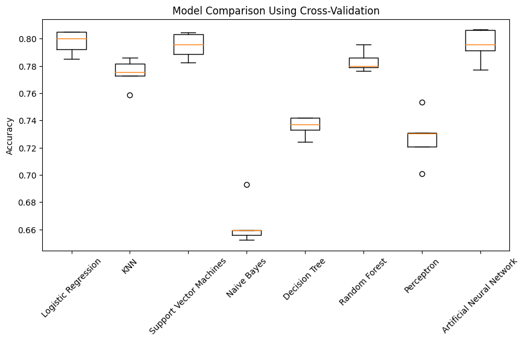

```python
results = []
names = []

for name, model in models:
    cv_scores = cross_val_score(model, X_train_scaled, y_train, cv=5, scoring='accuracy')
    results.append(cv_scores)
    names.append(name)
    print(f"{name}: {cv_scores.mean():.3f} ({cv_scores.std():.3f})")

plt.figure(figsize=(10, 5))
plt.boxplot(results)
plt.xticks(range(1, len(names) + 1), names, rotation=45)
plt.ylabel('Accuracy')
plt.title('Model Comparison Using Cross-Validation')
plt.show()
```

```
Accuracy: 0.8211497515968772
Classification report:
              precision    recall  f1-score   support

           0       0.86      0.90      0.88      1036
           1       0.69      0.60      0.64       373

    accuracy                           0.82      1409
   macro avg       0.77      0.75      0.76      1409
weighted avg       0.81      0.82      0.82      1409

Confusion matrix:
[[935 101]
 [151 222]]
```

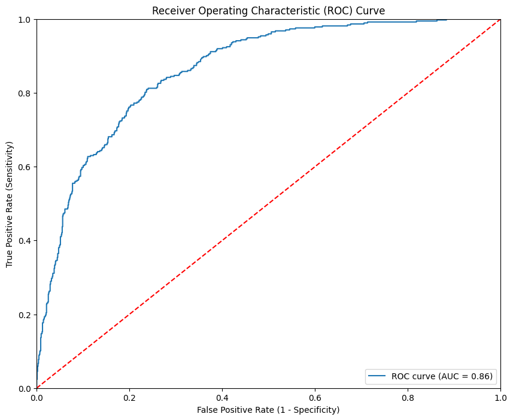

```python
from sklearn.metrics import accuracy_score, classification_report, confusion_matrix
from sklearn.metrics import roc_auc_score, roc_curve
from sklearn.metrics import precision_score, recall_score, f1_score

L_model = LogisticRegression(solver='liblinear')


L_model.fit(X_train_scaled, y_train)

y_pred = L_model.predict(X_test_scaled)

# Evaluate the model's performance
Logistic_accuracy = accuracy_score(y_test, y_pred)
print(f"Accuracy: {Logistic_accuracy}")

print("Classification report:")
print(classification_report(y_test, y_pred))

print("Confusion matrix:")
print(confusion_matrix(y_test, y_pred))

# calculate the probabilities on the test data
y_pred_prob = L_model.predict_proba(X_test_scaled)[:,1]

# calculate ROC curve
fpr, tpr, thresholds = roc_curve(y_test, y_pred_prob)

# calculate AUC
auc_score = roc_auc_score(y_test, y_pred_prob)

# plot the ROC curve
plt.figure(figsize=(10,8))
plt.plot(fpr, tpr, label='ROC curve (AUC = %0.2f)' % auc_score)
plt.plot([0, 1], [0, 1], linestyle='--', color='red') # diagonal line representing random classifier
plt.xlim([0.0, 1.0])
plt.ylim([0.0, 1.0])
plt.xlabel('False Positive Rate (1 - Specificity)')
plt.ylabel('True Positive Rate (Sensitivity)')
plt.title('Receiver Operating Characteristic (ROC) Curve')
plt.legend(loc="lower right")
plt.show()
```

Let's try Support Vector Machines

```python
# build a Support Vector Machines model and evaluate its performance
SVM_model = SVC()
SVM_model.fit(X_train_scaled, y_train)
SVM_Pred = SVM_model.predict(X_test_scaled)

# Evaluate the model's performance
SVM_accuracy = accuracy_score(y_test, SVM_Pred)
print(f"Accuracy: {SVM_accuracy}")

print("Classification report:")
print(classification_report(y_test, SVM_Pred))

print("Confusion matrix:")
print(confusion_matrix(y_test, SVM_Pred))
```

```
Accuracy: 0.8069552874378992
Classification report:
              precision    recall  f1-score   support

           0       0.84      0.92      0.87      1036
           1       0.68      0.50      0.58       373

    accuracy                           0.81      1409
   macro avg       0.76      0.71      0.73      1409
weighted avg       0.80      0.81      0.80      1409

Confusion matrix:
[[949  87]
 [185 188]]
```

Let's try ANN

```python
ann = MLPClassifier(max_iter=6000)
ann.fit(X_train_scaled, y_train)

ann_pred = ann.predict(X_test_scaled)
```

```
Accuracy: 0.7977288857345636
Confusion Matrix:
 [[928 108]
 [177 196]]
Classification report:
              precision    recall  f1-score   support

           0       0.84      0.90      0.87      1036
           1       0.64      0.53      0.58       373

    accuracy                           0.80      1409
   macro avg       0.74      0.71      0.72      1409
weighted avg       0.79      0.80      0.79      1409
```

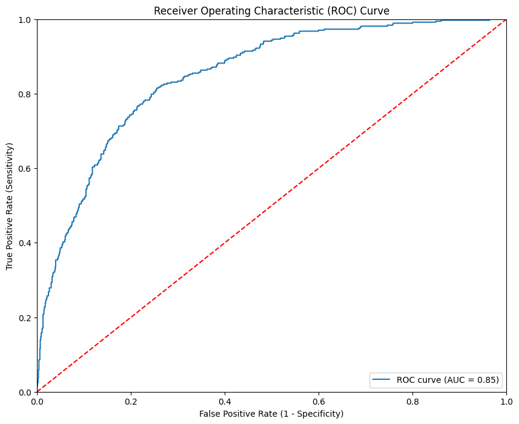

```python
conf_matrix = confusion_matrix(y_test, ann_pred)

ANN_accuracy = accuracy_score(y_test, ann_pred)

print(f"Accuracy: {ANN_accuracy}")

print("Confusion Matrix:\n", conf_matrix)
print("Classification report:")
print(classification_report(y_test, ann_pred))

# calculate the probabilities on the test data
ann_pred_prob = ann.predict_proba(X_test_scaled)[:,1]

# calculate ROC curve
fpr, tpr, thresholds = roc_curve(y_test, ann_pred_prob)

# calculate AUC
ANN_auc_score = roc_auc_score(y_test, ann_pred_prob)

# plot the ROC curve
plt.figure(figsize=(10,8))
plt.plot(fpr, tpr, label='ROC curve (AUC = %0.2f)' % ANN_auc_score)
plt.plot([0, 1], [0, 1], linestyle='--', color='red') # diagonal line representing random classifier
plt.xlim([0.0, 1.0])
plt.ylim([0.0, 1.0])
plt.xlabel('False Positive Rate (1 - Specificity)')
plt.ylabel('True Positive Rate (Sensitivity)')
plt.title('Receiver Operating Characteristic (ROC) Curve')
plt.legend(loc="lower right")
plt.show()
```

The ANN, SVM and Logistic Regression models seem to be good at predicting customers who will not churn, but poor at identifying who is likely to churn.

Since the dataset has more non-churn customers than churn customers, the model may be biased towards the majority class, leading to a higher accuracy for non-churn predictions.